# Analysis of Montgomery County Traffic Violations

Loyal Lemurs

1 December 2016

## Analysis of Traffic Violations in Montgomery County, Maryland

**Question 1** **Observing the relationship between number of traffic violations with the color of the cars**

*SUMMARY* In our data set there is a wide variety of cars by color violating traffic rules. We wanted to find the maximum number of traffic violations occured by which particular color of the car? There is a misconception that often red colored cars are involved in traffic violations and hence we wanted to check if such a claim is true.

*R SCRIPT*

```r
#Reading the TrafficViolations.csv file
TrafficData <- read.csv(file.choose(), header = T)
attach(TrafficData)
#Gives a descriptive summary of the number of traffic violation incidents that have
#occured by various cars across different colors
summary(TrafficData$Color)
```

```
## Length  Class   Mode
##      0   NULL   NULL
```

```r
#Load the ggplot2 package
library(ggplot2)
#Creating a data frame including 2 car colors
trafficDataFrame <- data.frame(color = factor(c("BLACK","RED"), levels=c("BLACK","RED")),total_violations = c(127582, 51939))
trafficDataFrame
```

```
##   color total_violations
## 1 BLACK           127582
## 2   RED            51939
```

```r
#Creating a data frame including 5 car colors
trafficDataFrame2 <- data.frame(color = factor(c("BLACK","SILVER", "WHITE", "GRAY", "RED"), levels=c("BLACK","SILVER","WHITE","GRAY","RED")),total_violations = c(127582,118571,95783,68744,51939))
trafficDataFrame2
```

```
##    color total_violations
## 1  BLACK           127582
## 2 SILVER           118571
## 3  WHITE            95783
## 4   GRAY            68744
## 5    RED            51939
```

*PLOT*

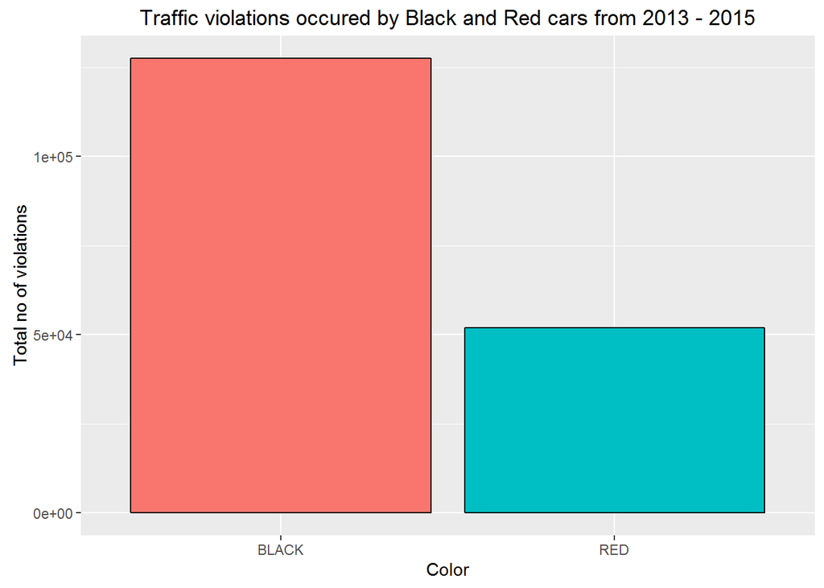

**DESCRIPTION** This is a plot that shows a comparison of top 5 colors of cars that are highly involved in traffic violations from the year 2013 to 2015. This is done using ggplot2 library in line graph format.It can be seen that Black, Silver, White, Gray and Red colored cars are involved in traffic violations in descending order.

*PLOT*

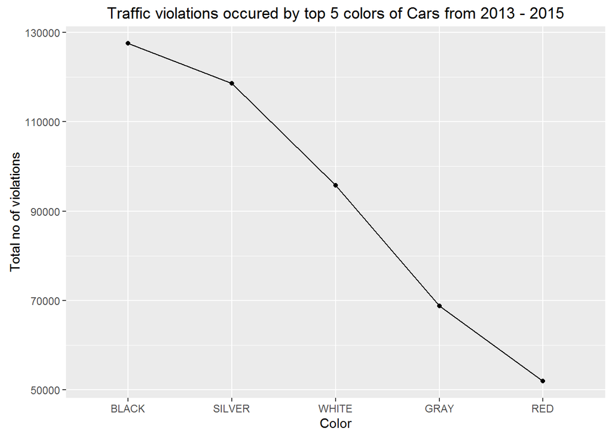

**DESCRIPTION** This plot is an enhanced version of the previous plot. I have used xkcd library to add a theme to my plot.

*PLOT*

```
## Registering fonts with R
```

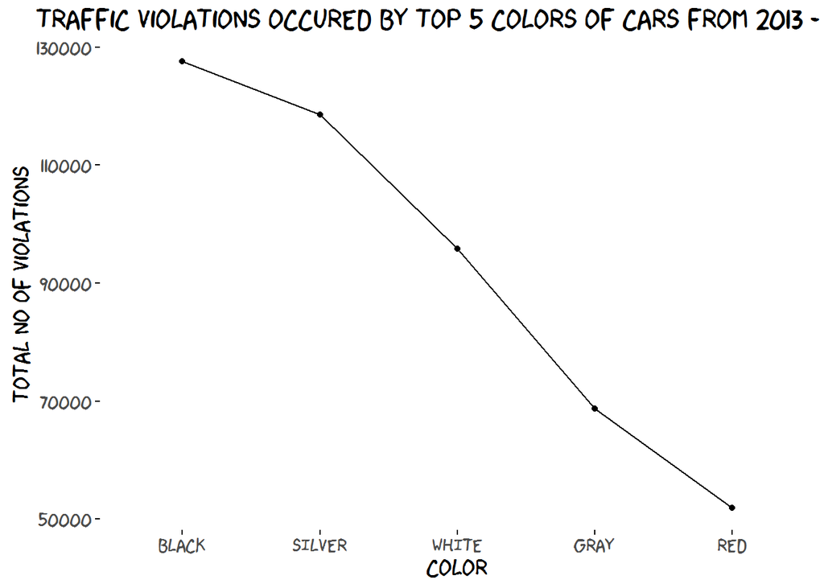

*R SCRIPT*

```r
#Subsetting dataset to find number of traffic violations occured during the year 2013 by BLACK colored cars
blackCar2013 <- subset(TrafficData, TrafficData$Year_Of_Stop =="2013" & TrafficData$Color == "BLACK")

#Subsetting dataset to find number of traffic violations occured during the year 2014 by BLACK colored cars
blackCar2014 <- subset(TrafficData, TrafficData$Year_Of_Stop =="2014" & TrafficData$Color == "BLACK")

#Subsetting dataset to find number of traffic violations occured during the year 2015 by BLACK colored cars
blackCar2015 <- subset(TrafficData, TrafficData$Year_Of_Stop =="2015" & TrafficData$Color == "BLACK")

#Storing the count of violations in three different years in 3 variables
blackCarCount2013 <- nrow(blackCar2013)

blackCarCount2014 <- nrow(blackCar2014)

blackCarCount2015 <- nrow(blackCar2015)

#Creating a data frame using count of traffic violations in these 3 years.
trafficDataFrameYearwise <- data.frame(year = factor(c("2013","2014","2015"), levels=c("2013","2014","2015")),total_violations = c(36573, 43450, 47559))
trafficDataFrameYearwise
```

```
##   year total_violations
## 1 2013            36573
## 2 2014            43450
## 3 2015            47559
```

*DESCRIPTION*

This plot is done using ggplot2 library and describes year wise trend of traffic violations occured from 2013 to 2015 by **Black** colored cars.

*PLOT*

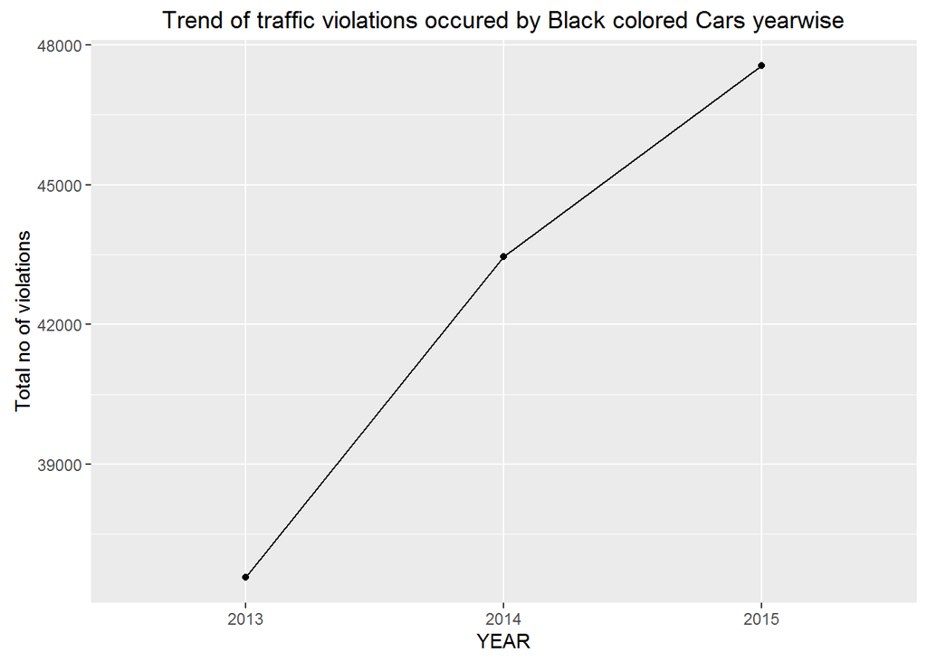

**Question 2a** **Observing the relationship between number of traffic violations during rush and non-rush hours**

*SUMMARY* I wanted to know if there is any difference in the number of traffic violations in Montogomery County during Rush hours and Non-Rush Hours.

Rush Hours - AM 06:00:00 AM -09:00:00 Rush Hours - PM 04:00:00 PM- 06:30:00

Non Rush Hours Rest of the time.

*R SCRIPT*

```r
#Calculations for the YEAR 2013

#Subsetting data to find evening Rush hours for the year 2013
TrafficDataRushHourPM2013 <- subset(TrafficData, TrafficData$Year_Of_Stop == "2013" &  TrafficData$Rush.Hour == "Rush Hour - PM")
#Subsetting data to find morning Rush hours for the year 2013
TrafficDataRushHourAM2013 <- subset(TrafficData, TrafficData$Year_Of_Stop == "2013" & TrafficData$Rush.Hour == "Rush Hour - AM")
#Subsetting data to find Non Rush hours for the year 2013
TrafficDataNonRushHr2013 <- subset(TrafficData, TrafficData$Year_Of_Stop == "2013" &  TrafficData$Rush.Hour == "Non-Rush Hour")

#Assigning total count of traffic violations to variables
RushHrAM2013Count <- nrow(TrafficDataRushHourAM2013)

RushHrPM2013Count <- nrow(TrafficDataRushHourPM2013)

NonRushHr2013Count <- nrow(TrafficDataNonRushHr2013)

#Normalizing value for RushHr2013Count variable
#Since our Rush Hour period is calculated for 6 hours in the whole day
#and non-rush hour period is calculated for 18 hours we need to normalize our RushHrTotal
#variable by multiplying it by 3
RushHr2013Count <- RushHrAM2013Count + RushHrPM2013Count
NormRushHr2013Count <- RushHr2013Count * 3 #Normalized Value


#Calculations for the YEAR 2014

#Subsetting data to find evening Rush hours for the year 2014
TrafficDataRushHourPM2014 <- subset(TrafficData, TrafficData$Year_Of_Stop == "2014" &  TrafficData$Rush.Hour == "Rush Hour - PM")
#Subsetting data to find morning Rush hours for the year 2013
TrafficDataRushHourAM2014 <- subset(TrafficData, TrafficData$Year_Of_Stop == "2014" & TrafficData$Rush.Hour == "Rush Hour - AM")
#Subsetting data to find Non Rush hours for the year 2013
TrafficDataNonRushHr2014 <- subset(TrafficData, TrafficData$Year_Of_Stop == "2014" &  TrafficData$Rush.Hour == "Non-Rush Hour")

#Assigning total count of traffic violations to variables
RushHrAM2014Count <- nrow(TrafficDataRushHourAM2014)

RushHrPM2014Count <- nrow(TrafficDataRushHourPM2014)

NonRushHr2014Count <- nrow(TrafficDataNonRushHr2014)

#Normalizing value for RushHr2014Count variable
#Since our Rush Hour period is calculated for 6 hours in the whole day
#and non-rush hour period is calculated for 18 hours we need to normalize our RushHrTotal
#variable by multiplying it by 3
RushHr2014Count <- RushHrAM2014Count + RushHrPM2014Count
NormRushHr2014Count <- RushHr2014Count * 3 #Normalized Value


#Calculations for the YEAR 2015

#Subsetting data to find evening Rush hours for the year 2015
TrafficDataRushHourPM2015 <- subset(TrafficData, TrafficData$Year_Of_Stop == "2015" &  TrafficData$Rush.Hour == "Rush Hour - PM")
#Subsetting data to find morning Rush hours for the year 2013
TrafficDataRushHourAM2015 <- subset(TrafficData, TrafficData$Year_Of_Stop == "2015" & TrafficData$Rush.Hour == "Rush Hour - AM")
#Subsetting data to find Non Rush hours for the year 2013
TrafficDataNonRushHr2015 <- subset(TrafficData, TrafficData$Year_Of_Stop == "2015" &  TrafficData$Rush.Hour == "Non-Rush Hour")

#Assigning total count of traffic violations to variables
RushHrAM2015Count <- nrow(TrafficDataRushHourAM2015)

RushHrPM2015Count <- nrow(TrafficDataRushHourPM2015)

NonRushHr2015Count <- nrow(TrafficDataNonRushHr2015)

#Normalizing value for RushHr2015Count variable
#Since our Rush Hour period is calculated for 6 hours in the whole day
#and non-rush hour period is calculated for 18 hours we need to normalize our RushHrTotal
#variable by multiplying it by 3
RushHr2015Count <- RushHrAM2015Count + RushHrPM2015Count
NormRushHr2015Count <- RushHr2015Count * 3 #Normalized Value

#Creating a data frame to store count of traffic violations during rush and non-rush hours during 2013, 2014 and 2015
RushHourPlot <- data.frame(Duration = factor(c("Rush Hour","Rush Hour","Rush Hour","Non-Rush Hour","Non-Rush Hour","Non-Rush Hour")),year = factor(c("2013","2014","2015","2013","2014","2015"), levels=c("2013","2014","2015")),total_violations = c(129414, 150903, 152262, 147227,173140,184348))
```

*DESCRIPTION* This is a bar graph plot using ggplot2 library to display the comparative no. of traffic violations during rush and non-rush hours over a period of time. It shows that violations have kept increaing since 2013 to 2015 both during rush and non-rush hours.

*PLOT*

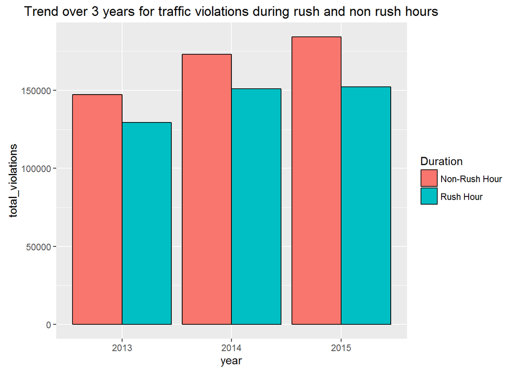

*DESCRIPTION* This plot is enhanced using xkcd theme. It is the same plot in the form of a bar graph but with a more enhanced theme using xkcd library.

*PLOT*

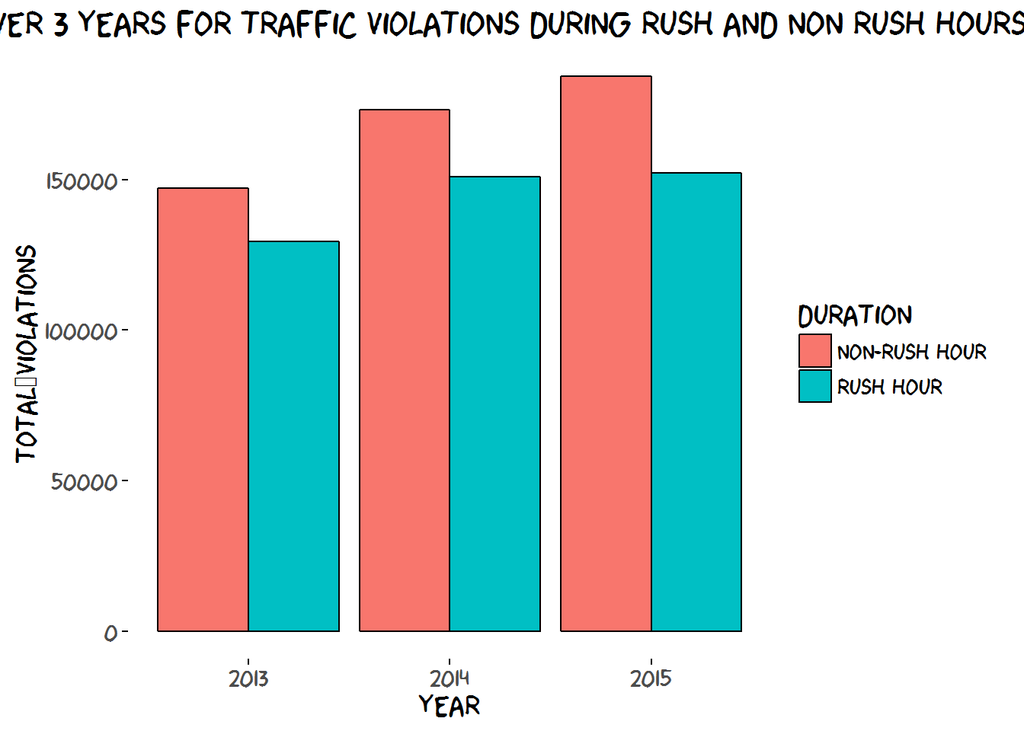

*DESCRIPTION* Using xkcd theme, the plot provides labels describing the number of violations for the plot.

*PLOT*

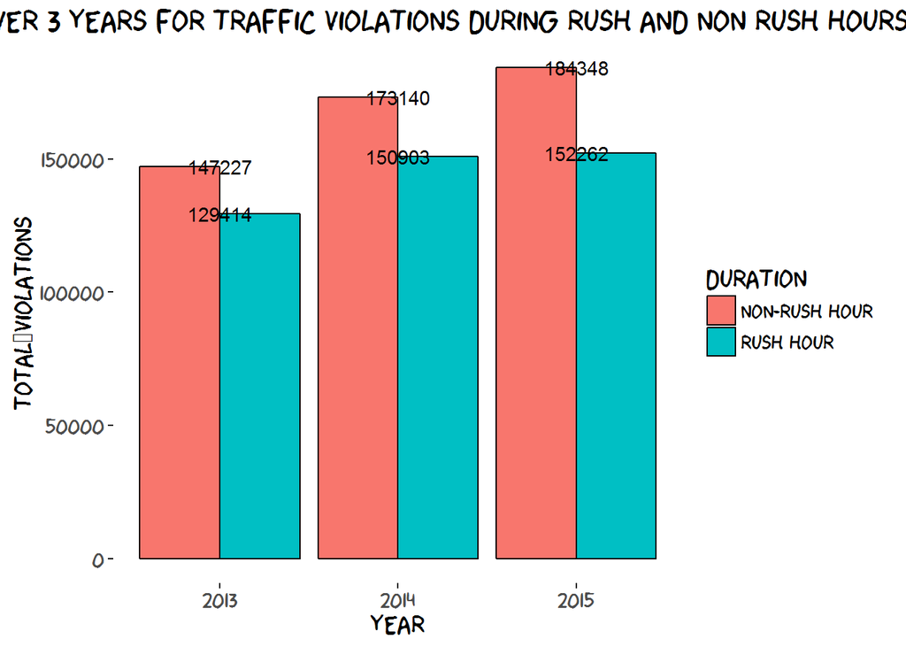

```r
#Enhancing the plot
ggplot(data=RushHourPlot, aes(x=year, y=total_violations, fill=Duration)) +geom_bar(stat="identity", position=position_dodge(),colour="black") + ggtitle("Trend over 3 years for traffic violations during rush and non rush hours") + geom_text(aes(x=year, y=total_violations,label=total_violations),family="Humor Sans")+theme_xkcd()
```

**Question 2b**

**Is there an effect of Season on the number of Traffic Violations caused?**

*DESCRIPTION* The line-plot given below represents a percentage wise division of the total number of violations in the years 2013-2015 by the Season in which they were recorded. The x-axis of the plot contains the “Season” values and the y-axis contains the percentage values of the number of violations. A point has been plotted against every Season on the x-axis, which represents its corresponding violation percentage value on the y-axis. These points have been connected by a line to form a line-plot. The plot shows that there is a considerable decrease in the number of violations occuring in winter.

```
## Using  as id variables
```

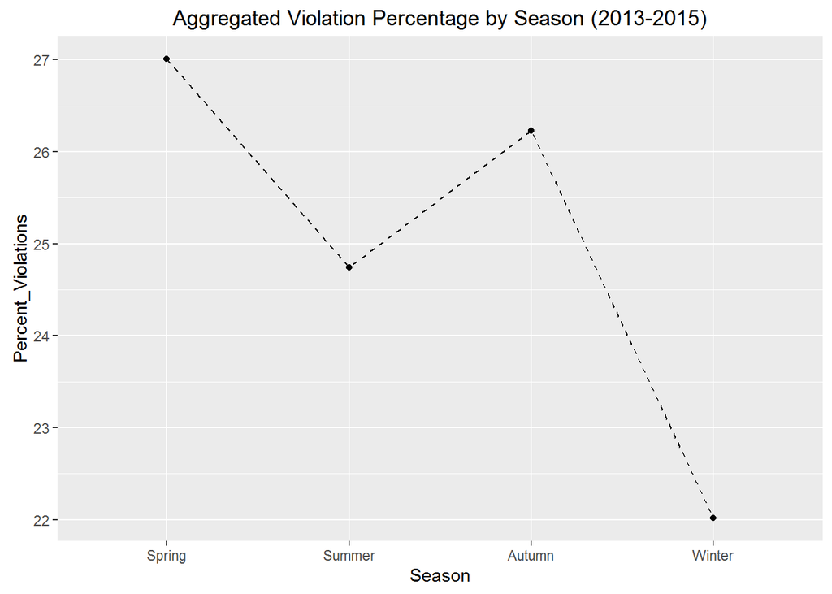

```r
Seasonline = ggplot(longSeason, aes(Season, Percent_Violations))
Seasonline + stat_summary(fun.y = mean, geom = "point") + stat_summary(fun.y = mean, geom = "line", aes(group = 1), color = "Black", linetype = "dashed") + xlab("Season") + ylab("Percent_Violations") + ggtitle("Aggregated Violation Percentage by Season (2013-2015)")
```

*DESCRIPTION* We can analyze whether this pattern of decreased violation percentage in Winter is consistent when we break-down the plot into individual years. This can be achieved using a multi-line plot. The multi-line plot shown below contains three line graphs which are color coded to represent a particular year. The red line graph represents the year 2013, the green line-graph represents the year 2014 and the blue line-graph represents the year 2015. A legend has been provided with the color labels corresponding to a particular year. As seen from the plot the percentage of violations drops in Winter during all three years (2013, 2014 & 2015)

```r
library(xkcd)
library(extrafont)
font_import(pattern = "[X/x]kcd", prompt = FALSE)
```

[output not shown]

[output not shown]

```
## C:\Windows\Fonts\xkcd.ttf
```

[output not shown]

```
## Found FontName for 0 fonts.
```

[output not shown]

```r
fonts()
```

```
## [1] "xkcd"
```

```r
loadfonts(device = "win")
```

```
## xkcd already registered with windowsFonts().
```

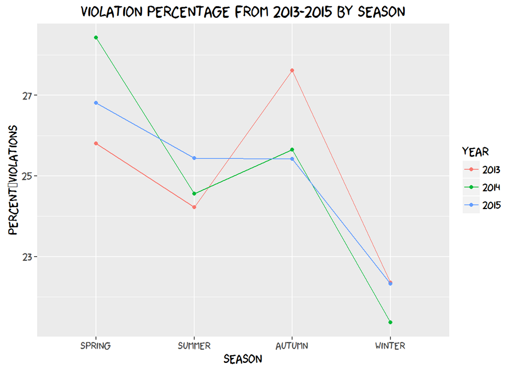

```r
#multi line graph
Seasonline = ggplot(longSeason, aes(Season, Percent_Violations, color = Year))
Seasonline + stat_summary(fun.y = mean, geom = "point") + stat_summary(fun.y = mean, geom = "line", aes(group = Year)) + xlab("Season") + ylab("Percent_Violations") + ggtitle("Violation Percentage from 2013-2015 by Season") + theme(text = element_text(size = 14,family = "xkcd"))
```

**Question 3**

**Does belonging to a particular race increase the probability of being issued a violation ?**

*DESCRIPTION* The grouped bar plot shown below below shows a comparison between the violation percentage and the demographic percentage of people of different races inhabiting the DMV area. The x-axis contains the Race information and the y-axis contains the percentage value. The legend diplayed indicates which barplot can be used to analyze what information. The blue barplot are indicators of the violation percentage whereas the pink barplots are indicators of the demographic percentage. Pink as well as blue barplots have been displayed to give a comparison for every Race. Ideally we would assume that the percentage of violations issued to people of a particular Race would resemble their demographic percentage. The grouped barplot can be used to analyze whether any given Race has been targetted more by the police department.

```r
library(ggplot2)
library(xkcd)
library(extrafont)
font_import(pattern = "[X/x]kcd", prompt = FALSE)
```

[output not shown]

[output not shown]

```
## C:\Windows\Fonts\xkcd.ttf
```

[output not shown]

```
## Found FontName for 0 fonts.
```

[output not shown]

```r
fonts()
```

```
## [1] "xkcd"
```

```r
loadfonts(device = "win")
```

```
## xkcd already registered with windowsFonts().
```

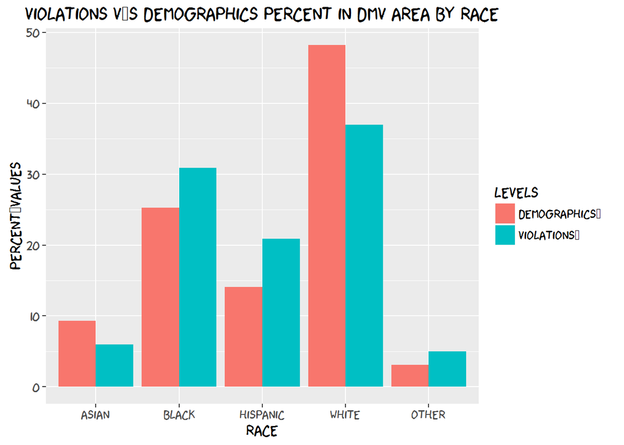

```r
#plot grouped bar plot
Racebar = ggplot(longRace, aes(Race, Value, fill = Levels))
Racebar + stat_summary(fun.y = mean, geom = "bar", position = "dodge") + ylab("Percent_Values") + ggtitle("Violations v/s Demographics percent in DMV Area by Race") + theme(text = element_text(size = 14,family = "xkcd"))
```